# Data manipulations

```r
print(iqr_low)
```

```
##   25%
## 159.5
```

```r
print(iqr_high)
```

```
## 75%
## 265
```

Now M_rr_syst (systolic blood pressure):

```r
shapiro.test(part1$M_rr_syst) # w=0.99, p=1.4e-05
```

```
##
##  Shapiro-Wilk normality test
##
## data:  part1$M_rr_syst
## W = 0.99002, p-value = 1.403e-05
```

Histogram:

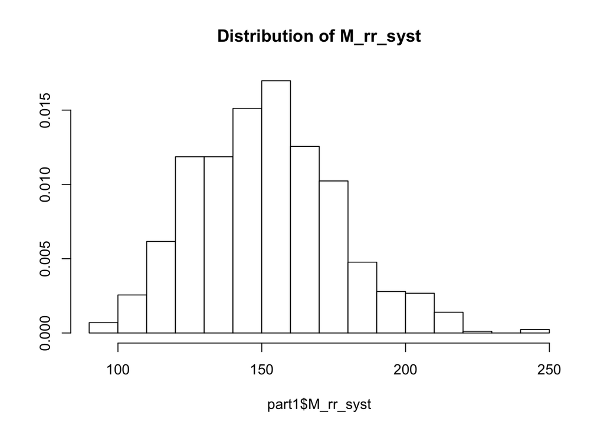

```r
par(mfrow=c(1,1))
truehist(part1$M_rr_syst, main = "Distribution of M_rr_syst", col = "white")
```

QQ plot:

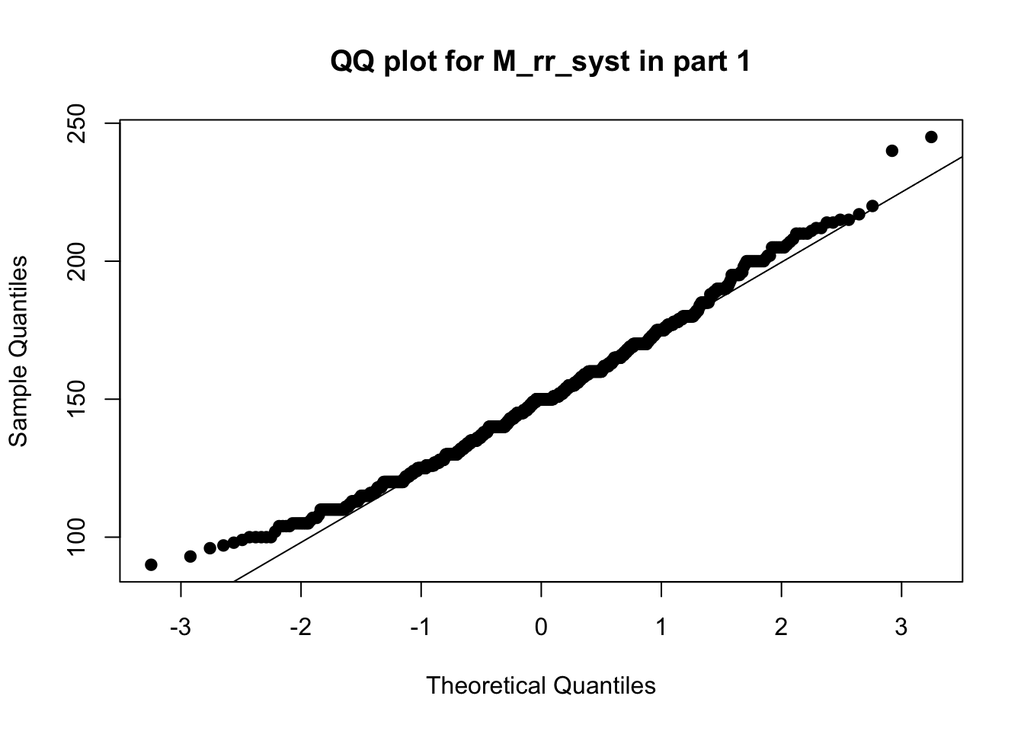

```r
qqnorm(part1$M_rr_syst, main = "QQ plot for M_rr_syst in part 1", pch=19)
qqline(part1$M_rr_syst)
```

Calculate the median and IQR values:

```r
median <- median(part1$M_rr_syst, na.rm = TRUE)
iqr <- IQR(part1$M_rr_syst, na.rm = TRUE)
iqr_low <- quantile(part1$M_rr_syst, na.rm = TRUE)[2]
iqr_high <- quantile(part1$M_rr_syst, na.rm = TRUE)[4]
print(median)
```

```
## [1] 150
```

```r
print(iqr_low)
```

```
##    25%
## 131.75
```

```r
print(iqr_high)
```

```
## 75%
## 166
```

Other clinical variables were factors and hence the total number with percentage was calculated: Sex, female or male

```r
total.men<- summary(part1$M_sex)[2]
percentage <- ((summary(part1$M_sex)[2])/887)*100
print(total.men,0)
```

```
## Male
##  461
```

```r
print(percentage,0)
```

```
## Male
##   52
```

Hypertension, Yes or No

```r
total.ht<- summary(part1$M_prev_ht)[2]
percentage <- ((summary(part1$M_prev_ht)[2])/887)*100
print(total.ht,0)
```

```
## Yes
## 446
```

```r
print(percentage,0)
```

```
## Yes
##  50
```

Diabetes mellitus, Yes or No

```r
total.dm<- summary(part1$M_prev_dm)[2]
percentage <- ((summary(part1$M_prev_dm)[2])/887)*100
print(total.dm,0)
```

```
## Yes
## 136
```

```r
print(percentage,0)
```

```
## Yes
##  15
```

Previous ischemic stroke, Yes or No

```r
total.str<- summary(part1$M_prev_str)[2]
percentage <- ((summary(part1$M_prev_str)[2])/887)*100
print(total.str,0)
```

```
## Yes
## 159
```

```r
print(percentage,0)
```

```
## Yes
##  18
```

Atrial fibrillation, Yes or No

```r
total.af<- summary(part1$M_prev_af)[2]
percentage <- ((summary(part1$M_prev_af)[2])/887)*100
print(total.af,0)
```

```
## Yes
## 202
```

```r
print(percentage,0)
```

```
## Yes
##  23
```

Prestroke modified ranking scale, 0, 1, 2 >3

```r
total.0 <- summary(part1$M_premrs)[1]
percentage <- ((summary(part1$M_premrs)[1])/887)*100
print(total.0,0) # mrs 0
```

```
## Min.
##    0
```

```r
print(percentage,0)
```

```
## Min.
##    0
```

```r
total.1 <- summary(part1$M_premrs)[2]
percentage <- ((summary(part1$M_premrs)[2])/887)*100
print(total.1,0) # mrs 1
```

```
## 1st Qu.
##       0
```

```r
print(percentage,0)
```

```
## 1st Qu.
##       0
```

```r
total.2 <- summary(part1$M_premrs)[3]
percentage <- ((summary(part1$M_premrs)[3])/887)*100
print(total.2,0) # mrs 2
```

```
## Median
##      0
```

```r
print(percentage,0)
```

```
## Median
##      0
```

```r
total.35 <- (summary(part1$M_premrs)[4])+(summary(part1$M_premrs)[5])+(summary(part1$M_premrs)[6])
percentage <- (total.35/887)*100
print(total.35,0) # mrs >3
```

```
## Mean
##    7
```

```r
print(percentage,0)
```

```
## Mean
##    1
```

## Treatment variable distributions

Now for M_durproc (duration of the procedure):

```r
shapiro.test(part1$M_durproc) # w=0.95, p=3.2e-15
```

```
##
##  Shapiro-Wilk normality test
##
## data:  part1$M_durproc
## W = 0.95331, p-value = 3.227e-15
```

Histogram:

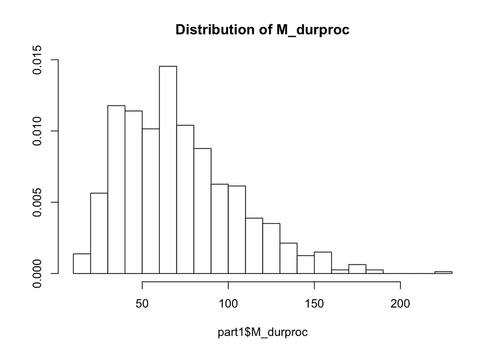

```r
par(mfrow=c(1,1))
truehist(part1$M_durproc, main = "Distribution of M_durproc", col = "white")
```

QQ plot:

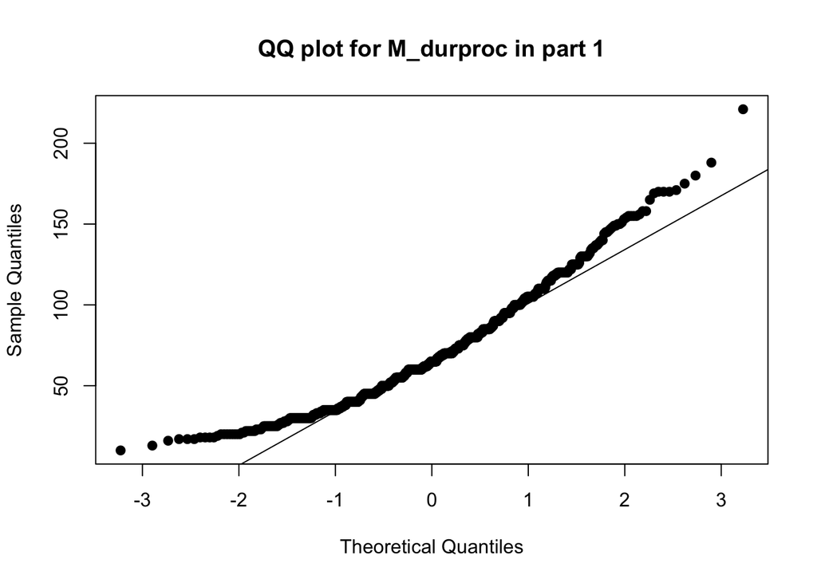

```r
qqnorm(part1$M_durproc, main = "QQ plot for M_durproc in part 1", pch=19)
qqline(part1$M_durproc)
```

Calculate the median and IQR values:

```r
median <- median(part1$M_durproc, na.rm = TRUE)
iqr <- IQR(part1$M_durproc, na.rm = TRUE)
iqr_low <- quantile(part1$M_durproc, na.rm = TRUE)[2]
iqr_high <- quantile(part1$M_durproc, na.rm = TRUE)[4]
print(median)
```

```
## [1] 65
```

```r
print(iqr_low)
```

```
## 25%
##  45
```

```r
print(iqr_high)
```

```
## 75%
##  90
```

Other treatment variables were factors and hence the total number with percentage was calculated: Failed femoral approach, Yes or No

```r
part1$Mc_FailedFemoralApproach <- factor(part1$Mc_FailedFemoralApproach)
total.failed <- summary(part1$Mc_FailedFemoralApproach)[2]
percentage <- ((summary(part1$Mc_FailedFemoralApproach)[2])/887)*100
print(total.failed,0)
```

```
##  1
## 59
```

```r
print(percentage,0)
```

```
## 1
## 7
```

Treatment with IV alteplase, Yes or No

```r
total.1 <- summary(part1$M_ivtrom)[1]
percentage <- ((summary(part1$M_ivtrom)[1])/887)*100
print(total.1,0) # ivtrom No
```

```
##   1
## 204
```

```r
print(percentage,0)
```

```
##  1
## 23
```

```r
total.2 <- summary(part1$M_ivtrom)[2]
percentage <- ((summary(part1$M_ivtrom)[2])/887)*100
print(total.2,0) # ivtrom Yes
```

```
##   2
## 683
```

```r
print(percentage,0)
```

```
##  2
## 77
```

Post-eTICI, 0, 1, 2(A-C), 3

```r
total.ptici0<- summary(part1$M_posttici_c)[1] # postici 0
percentage <- (total.ptici0/887)*100
print(total.ptici0,0)
```

```
##   0
## 171
```

```r
print(percentage,0)
```

```
##  0
## 19
```

```r
total.ptici1<- summary(part1$M_posttici_c)[2] # postici 1
percentage <- (total.ptici1/887)*100
print(total.ptici1,0)
```

```
##  1
## 32
```

```r
print(percentage,0)
```

```
## 1
## 4
```

```r
total.ptici2a<- summary(part1$M_posttici_c)[3] # postici 2A
percentage <- (total.ptici2a/887)*100
print(total.ptici2a,0)
```

```
##  2A
## 192
```

```r
print(percentage,0)
```

```
## 2A
## 22
```

```r
total.ptici2b<- summary(part1$M_posttici_c)[4] # postici 2B
percentage <- (total.ptici2b/887)*100
print(total.ptici2b,0)
```

```
##  2B
## 162
```

```r
print(percentage,0)
```

```
## 2B
## 18
```

```r
total.ptici2c<- summary(part1$M_posttici_c)[5] # postici 2C
percentage <- (total.ptici2c/887)*100
print(total.ptici2c,0)
```

```
## 2C
## 85
```

```r
print(percentage,0)
```

```
## 2C
## 10
```

```r
total.ptici3<- summary(part1$M_posttici_c)[6] # postici 3
percentage <- (total.ptici3/887)*100
print(total.ptici3,0)
```

```
##   3
## 235
```

```r
print(percentage,0)
```

```
##  3
## 26
```

## Imaging variable distributions

Continue on with M_ASPECTS_BL (baseline ASPECTS score; determines severity of the stroke by looking at the penetration in several brain areas):

```r
shapiro.test(part1$M_ASPECTS_BL) # w=0.83, p=2.2e-16
```

```
##
##  Shapiro-Wilk normality test
##
## data:  part1$M_ASPECTS_BL
## W = 0.83788, p-value < 2.2e-16
```

Histogram:

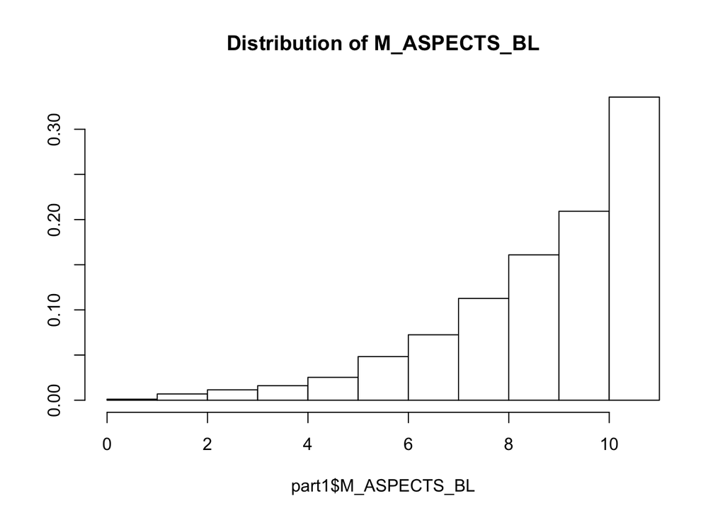

```r
par(mfrow=c(1,1))
truehist(part1$M_ASPECTS_BL, main = "Distribution of M_ASPECTS_BL", col = "white")
```

QQ plot:

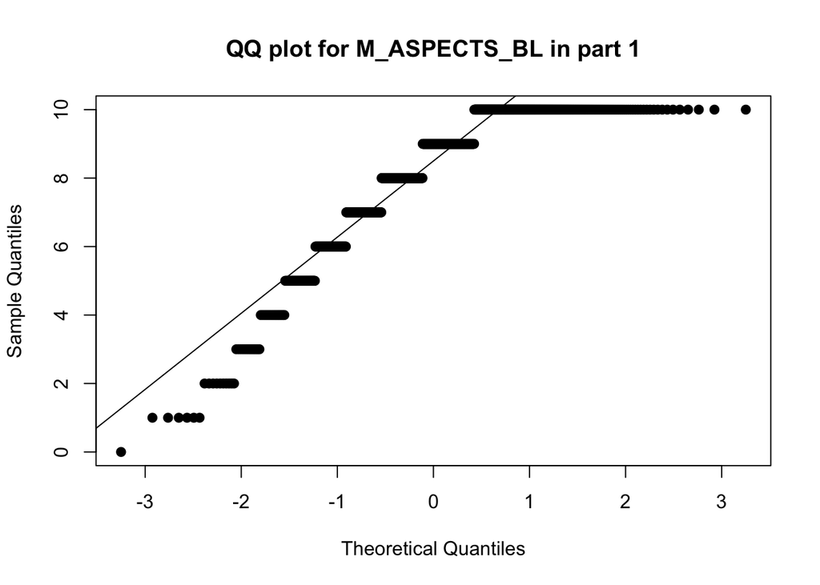

```r
qqnorm(part1$M_ASPECTS_BL, main = "QQ plot for M_ASPECTS_BL in part 1", pch=19)
qqline(part1$M_ASPECTS_BL)
```

Calculate the median and IQR values:

```r
median <- median(part1$M_ASPECTS_BL, na.rm = TRUE)
iqr <- IQR(part1$M_ASPECTS_BL, na.rm = TRUE)
iqr_low <- quantile(part1$M_ASPECTS_BL, na.rm = TRUE)[2]
iqr_high <- quantile(part1$M_ASPECTS_BL, na.rm = TRUE)[4]
print(median)
```

```
## [1] 9
```

```r
print(iqr_low)
```

```
## 25%
##   7
```

```r
print(iqr_high)
```

```
## 75%
##  10
```

Now the last numeric variable in part1, M_CBS_BL (clot burden score):

```r
shapiro.test(part1$M_CBS_BL) # w=0.93, p=2.2e-16
```

```
##
##  Shapiro-Wilk normality test
##
## data:  part1$M_CBS_BL
## W = 0.93666, p-value < 2.2e-16
```

Histogram:

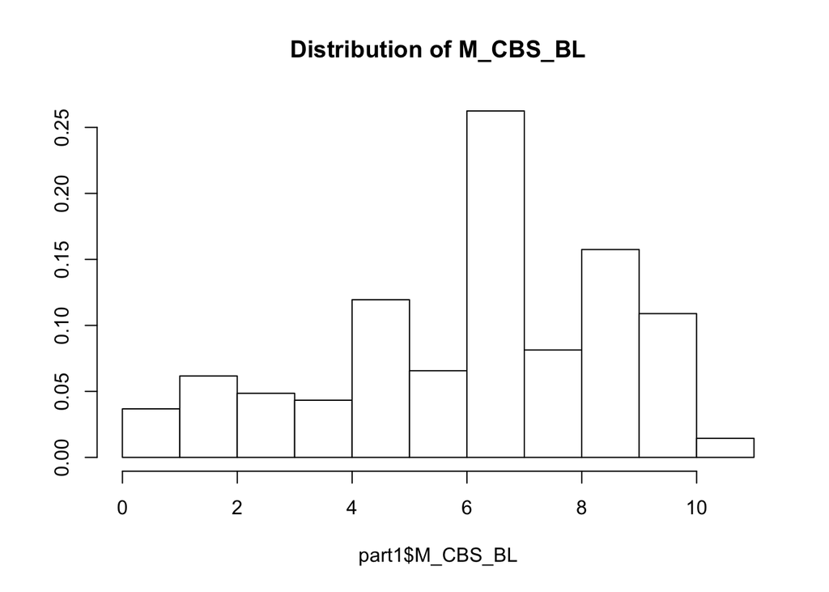

```r
par(mfrow=c(1,1))
truehist(part1$M_CBS_BL, main = "Distribution of M_CBS_BL", col = "white")
```

QQ plot:

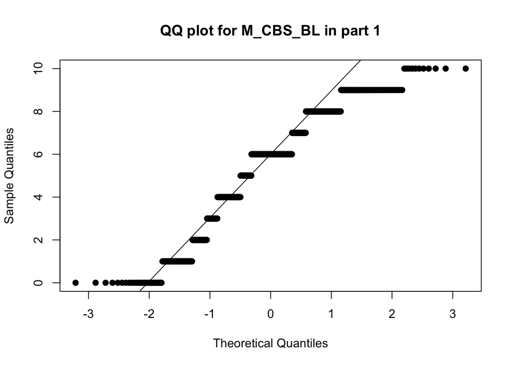

```r
qqnorm(part1$M_CBS_BL, main = "QQ plot for M_CBS_BL in part 1", pch=19)
qqline(part1$M_CBS_BL)
```

Median and IQR:

```r
median <- median(part1$M_CBS_BL, na.rm = TRUE)
iqr <- IQR(part1$M_CBS_BL, na.rm = TRUE)
iqr_low <- quantile(part1$M_CBS_BL, na.rm = TRUE)[2]
iqr_high <- quantile(part1$M_CBS_BL, na.rm = TRUE)[4]
print(median)
```

```
## [1] 6
```

```r
print(iqr_low)
```

```
## 25%
##   4
```

```r
print(iqr_high)
```

```
## 75%
##   8
```

Other imaging variables were factors and hence the total number with percentage was calculated: Pre-eTICI, 0, 1, 2A, 2B-3

```r
total.1 <- summary(part1$Mc_pretici_short)[1]
percentage <- ((summary(part1$Mc_pretici_short)[1])/887)*100
print(total.1,0) # pretici 0
```

```
##   0
## 713
```

```r
print(percentage,0)
```

```
##  0
## 80
```

```r
total.2 <- summary(part1$Mc_pretici_short)[2]
percentage <- ((summary(part1$Mc_pretici_short)[2])/887)*100
print(total.2,0) # pretici 1
```

```
##  1
## 54
```

```r
print(percentage,0)
```

```
## 1
## 6
```

```r
total.3 <- summary(part1$Mc_pretici_short)[3]
percentage <- ((summary(part1$Mc_pretici_short)[3])/887)*100
print(total.3,0) # pretici 2
```

```
## 2A
## 20
```

```r
print(percentage,0)
```

```
## 2A
##  2
```

```r
total.4 <- (summary(part1$Mc_pretici_short)[4])
percentage <- (total.4/887)*100
print(total.4,0) # pretici >3
```

```
## 2B - 3
##      9
```

```r
print(percentage,0)
```

```
## 2B - 3
##      1
```

```r
print(percentage,0)
```

```
## 2B - 3
##      1
```

Occlusion segment, ICA-I, ICA-T, M1, M2-M3

```r
total.1 <- summary(part1$M_occlsegment_c_short)[1]
percentage <- ((summary(part1$M_occlsegment_c_short)[1])/887)*100
print(total.1,0) # ICAI
```

```
## Intracranial ICA
##               52
```

```r
print(percentage,0)
```

```
## Intracranial ICA
##                6
```

```r
total.2 <- summary(part1$M_occlsegment_c_short)[2]
percentage <- ((summary(part1$M_occlsegment_c_short)[2])/887)*100
print(total.2,0) # ICAT
```

```
## ICA-T
##   203
```

```r
print(percentage,0)
```

```
## ICA-T
##    23
```

```r
total.3 <- summary(part1$M_occlsegment_c_short)[3]
percentage <- ((summary(part1$M_occlsegment_c_short)[3])/887)*100
print(total.3,0) # M1
```

```
##  M1
## 509
```

```r
print(percentage,0)
```

```
## M1
## 57
```

```r
total.4 <- summary(part1$M_occlsegment_c_short)[4]
percentage <- ((summary(part1$M_occlsegment_c_short)[4])/887)*100
print(total.4,0) # Other
```

```
## other:M3/anterior_M2
##                  110
```

```r
print(percentage,0)
```

```
## other:M3/anterior_M2
##                   12
```

Collateral score, absent, <50% filling, >50<100 filling, 100% of occluded area

```r
total.1 <- summary(part1$M_collaterals)[1]
percentage <- ((summary(part1$M_collaterals)[1])/887)*100
print(total.1,0) # absent
```

```
## absent collaterals
##                 55
```

```r
print(percentage,0)
```

```
## absent collaterals
##                  6
```

```r
total.2 <- summary(part1$M_collaterals)[2]
percentage <- ((summary(part1$M_collaterals)[2])/887)*100
print(total.2,0) # <50% fillin
```

```
## filling <50% of occluded area
##                           286
```

```r
print(percentage,0)
```

```
## filling <50% of occluded area
##                            32
```

```r
total.3 <- summary(part1$M_collaterals)[3]
percentage <- ((summary(part1$M_collaterals)[3])/887)*100
print(total.3,0) # >50<100 fillin
```

```
## >50% but less <100%
##                 337
```

```r
print(percentage,0)
```

```
## >50% but less <100%
##                  38
```

```r
total.4 <- (summary(part1$M_collaterals)[4])
percentage <- (total.4/887)*100
print(total.4,0) # 100% of occluded area
```

```
## 100% of occluded area
##                   175
```

```r
print(percentage,0)
```

```
## 100% of occluded area
##                    20
```

Prestroke modified ranking scale reversed, 0, 1, 2, >3

```r
total.0 <- summary(part1$M_premrs)[1]
percentage <- ((summary(part1$M_premrs)[1])/887)*100
print(total.0,0) #  0
```

```
## Min.
##    0
```

```r
print(percentage,0)
```

```
## Min.
##    0
```

```r
total.1 <- summary(part1$M_premrs)[2]
percentage <- ((summary(part1$M_premrs)[2])/887)*100
print(total.1,0) #  1
```

```
## 1st Qu.
##       0
```

```r
print(percentage,0)
```

```
## 1st Qu.
##       0
```

```r
total.2 <- summary(part1$M_premrs)[3]
percentage <- ((summary(part1$M_premrs)[3])/887)*100
print(total.2,0) #  2
```

```
## Median
##      0
```

```r
print(percentage,0)
```

```
## Median
##      0
```

```r
total.35 <- (summary(part1$M_premrs)[4])+(summary(part1$M_premrs)[5])+(summary(part1$M_premrs)[6])
percentage <- (total.35/887)*100
print(total.35,0) #  >3
```

```
## Mean
##    7
```

```r
print(percentage,0)
```

```
## Mean
##    1
```